# Data Mining Project - Analysis of Airbnb Rentals

### **Data Preprocessing**

```r
ny_ct.df <- ny.df
```

```r
# Subset data (remove unnecessary columns)
ny_ct.df <- subset(ny_ct.df, select= - c(id, amenities, bed_type, cleaning_fee, city, description, first_review, host_since,instant_bookable, last_review, latitude, longitude, name, thumbnail_url, neighbourhood, property_group, borough))
```

```r
# Inspect new dataset
str(ny_ct.df)
```

```
'data.frame':   15589 obs. of  14 variables:
 $ log_price             : num  5.39 4.7 5.66 4.93 5.19 ...
 $ property_type         : chr  "Apartment" "Apartment" "Apartment" "Apartment" ...
 $ room_type             : chr  "Entire home/apt" "Private room" "Entire home/apt" "Private room" ...
 $ accommodates          : int  2 4 2 3 2 1 8 6 3 3 ...
 $ bathrooms             : num  1 1 1 1 1 1 1 1 2 1 ...
 $ cancellation_policy   : Factor w/ 4 levels "flexible","moderate",..: 2 3 3 3 3 3 3 3 3 1 ...
 $ host_has_profile_pic  : chr  "t" "t" "t" "t" ...
 $ host_identity_verified: Factor w/ 2 levels "True","False": 2 1 1 2 1 2 1 1 2 2 ...
 $ host_response_rate    : num  1 1 1 0.5 1 0.96 1 1 1 0.9 ...
 $ number_of_reviews     : int  3 72 2 3 140 16 62 178 105 8 ...
 $ review_scores_rating  : num  1 0.91 0.9 1 0.82 0.95 0.93 0.83 0.92 0.98 ...
 $ bedrooms              : num  1 1 1 1 1 1 2 1 1 1 ...
 $ beds                  : num  1 1 1 2 2 1 4 3 1 1 ...
 $ amenities_count       : int  11 31 22 14 14 15 20 23 19 15 ...
```

```r
# Convert character variables to factors
ny_ct.df$property_type <- as.factor(ny_ct.df$property_type)
ny_ct.df$room_type <- as.factor(ny_ct.df$room_type)
ny_ct.df$host_has_profile_pic <- factor(ny_ct.df$host_has_profile_pic, levels = c("t", "f"), labels = c("True", "False"))

str(ny_ct.df) # reinspect dataset
```

```
'data.frame':   15589 obs. of  14 variables:
 $ log_price             : num  5.39 4.7 5.66 4.93 5.19 ...
 $ property_type         : Factor w/ 21 levels "Apartment","Bed & Breakfast",..: 1 1 1 1 1 1 1 1 1 9 ...
 $ room_type             : Factor w/ 3 levels "Entire home/apt",..: 1 2 1 2 1 2 1 1 2 1 ...
 $ accommodates          : int  2 4 2 3 2 1 8 6 3 3 ...
 $ bathrooms             : num  1 1 1 1 1 1 1 1 2 1 ...
 $ cancellation_policy   : Factor w/ 4 levels "flexible","moderate",..: 2 3 3 3 3 3 3 3 3 1 ...
 $ host_has_profile_pic  : Factor w/ 2 levels "True","False": 1 1 1 1 1 1 1 1 1 1 ...
 $ host_identity_verified: Factor w/ 2 levels "True","False": 2 1 1 2 1 2 1 1 2 2 ...
 $ host_response_rate    : num  1 1 1 0.5 1 0.96 1 1 1 0.9 ...
 $ number_of_reviews     : int  3 72 2 3 140 16 62 178 105 8 ...
 $ review_scores_rating  : num  1 0.91 0.9 1 0.82 0.95 0.93 0.83 0.92 0.98 ...
 $ bedrooms              : num  1 1 1 1 1 1 2 1 1 1 ...
 $ beds                  : num  1 1 1 2 2 1 4 3 1 1 ...
 $ amenities_count       : int  11 31 22 14 14 15 20 23 19 15 ...
```

Note: ‘cancellation’ & ‘host_identity_verified’ already a factor variable & we do not need to modify any levels yet.

```r
# Change levels to "strict","moderate", & "flexible"
levels(ny_ct.df$cancellation_policy)[levels(ny_ct.df$cancellation_policy) == "strict"] <- "strict"
levels(ny_ct.df$cancellation_policy)[levels(ny_ct.df$cancellation_policy) == "super_strict"] <- "strict"
levels(ny_ct.df$cancellation_policy)[levels(ny_ct.df$cancellation_policy) == "flexible"] <- "flexible"
levels(ny_ct.df$cancellation_policy)[levels(ny_ct.df$cancellation_policy) == "moderate"] <- "moderate"
```

```r
#Partition data into training & validation sets
set.seed(92)
ny_ct.df_train.index <- sample(c(1:nrow(ny_ct.df)), nrow(ny_ct.df)*0.6)
ny_ct_train.df <- ny_ct.df[ny_ct.df_train.index, ]
ny_ct_valid.df <- ny_ct.df[-ny_ct.df_train.index, ]
```

```r
#Build the classification tree model
ct <- rpart(cancellation_policy~., ny_ct_train.df, method="class", xval= 10)
```

```r
# Determine the ideal tree size using Cross-validation
printcp(ct)
```

```
Classification tree:
rpart(formula = cancellation_policy ~ ., data = ny_ct_train.df,
    method = "class", xval = 10)

Variables actually used in tree construction:
[1] log_price         number_of_reviews

Root node error: 4607/9353 = 0.5

n= 9353

    CP nsplit rel error xerror xstd
1 0.04      0       1.0    1.0 0.01
2 0.01      2       0.9    0.9 0.01
```

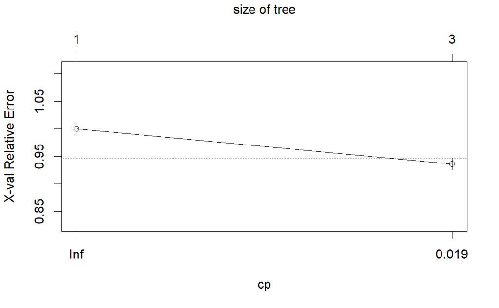

```r
# Determine the ideal tree size using Cross-validation
plotcp(ct)
```

```r
# Keep the tree size where the cp value has the smallest error
ct_pruned <- prune(ct,
                  cp = ct$cptable[which.min(ct$cptable[, "xerror"]), "CP"])
```

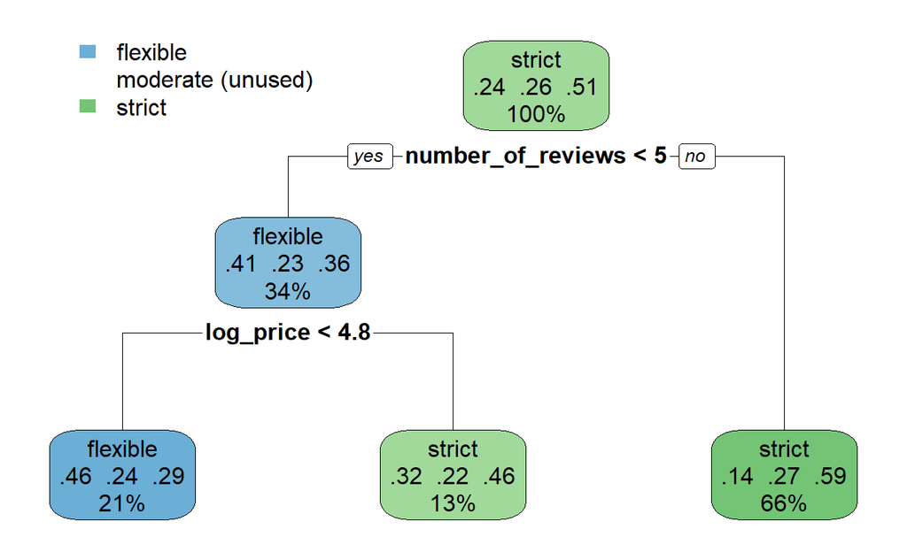

```r
# Plot the pruned tree
rpart.plot(ct_pruned, yesno = TRUE)
```

### **Explanation of Classification Tree:**

The Classification Tree model we constructed serves the purpose of predicting Airbnb hosts’ cancellation policies in New York City, a critical aspect for both hosts and guests to understand. Our journey began with a meticulous phase of data preparation, including the removal of redundant columns, data type conversions, and handling of missing values. To simplify the classification task, we consolidated two levels of the “cancellation_policy” variable into the broader “strict” category. Subsequently, we partitioned the dataset into two distinct sets: a training set (comprising 60% of the data) and a validation set (comprising 40%), ensuring adequate representation of both cancellation policy types.

The construction of the decision tree model was an iterative process, involving the exploration of potential features that might influence cancellation policies. After thorough analysis, two key variables emerged as significant contributors: the number of reviews and the log price. These variables play a crucial role in understanding and predicting cancellation policies for Airbnb listings in New York City.

# **Clustering - Comparison of Neighborhoods in NYC**

*k-Means Analysis is applied in an effort to compare the Brooklyn neighborhoods in NYC.*

### **Data Pre-Processing**

```r
# Subset Brooklyn neighbors to be used as labels
ny_cluster.df <- subset(ny.df, borough == "Brooklyn")
```

```r
# Create new variable to combine 'number_of_reviews' & 'review_scores_rating'
ny_cluster.df <- ny_cluster.df %>%
  mutate(avg_review_scores_rating = review_scores_rating/number_of_reviews)
```

```r
# Remove unnecessary columns
ny_cluster.df <- subset(ny_cluster.df, select= -c(id, property_type, room_type, amenities, bed_type, cancellation_policy, cleaning_fee, city, description, first_review, host_has_profile_pic, host_identity_verified, host_response_rate, host_since, instant_bookable, last_review, latitude, longitude, name, number_of_reviews, review_scores_rating, thumbnail_url, bedrooms, beds, borough, property_group))
```

```r
# Handle missing values
ny_cluster.df <- na.omit(ny_cluster.df)
```

```r
str(ny_cluster.df)  # Reinspect dataframe
```

```
'data.frame':   5846 obs. of  6 variables:
 $ log_price               : num  4.91 5.08 6.11 5.7 4.76 ...
 $ accommodates            : int  2 2 7 6 2 2 6 2 5 3 ...
 $ bathrooms               : num  1 2 2.5 2 1 1 2 1 1 1 ...
 $ neighbourhood           : chr  "DUMBO" "Boerum Hill" "Boerum Hill" "Downtown Brooklyn" ...
 $ amenities_count         : int  14 15 10 15 6 19 28 15 20 16 ...
 $ avg_review_scores_rating: num  0.0172 0.3333 0.1225 0.5 0.5 ...
```

```r
# Prepare data
cluster_labels = ny_cluster.df$neighbourhood
feature_var <- select(ny_cluster.df, -neighbourhood)

# Scale/standardize data to a mean of 0 & standard deviation of 1
df.scale <- scale(feature_var)
```

### **Determine optimal number of clusters (k)**

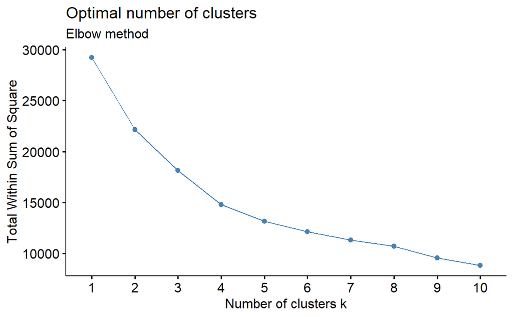

```r
# Compute distance between observations
ny_cluster.df.dist <- dist(df.scale)

# Determine 'k' value (# of clusters) using within sum squares
fviz_nbclust(df.scale, kmeans, method="wss") + labs(subtitle = "Elbow method")
```

### **k-Means Clustering**

```r
# k-means
optimal_k <- 4
km.out <- kmeans(df.scale, centers = optimal_k, nstart = 100)
```

### **Cluster Visualization/Interpretation**

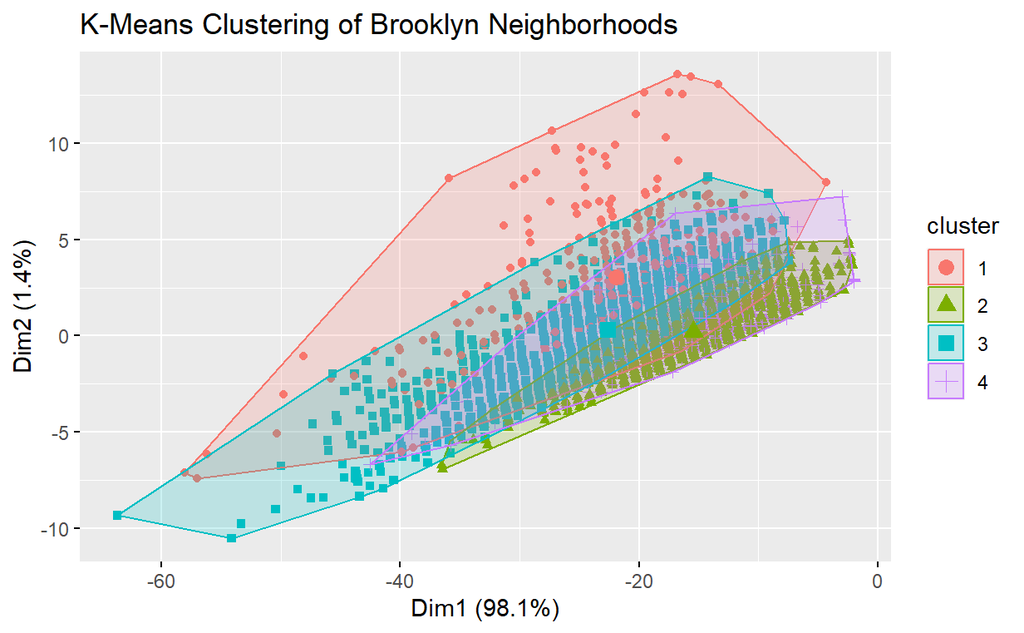

```r
fviz_cluster(km.out, data = feature_var, stand = FALSE,
             geom = "point", ellipse.type = "convex",
             main = "K-Means Clustering of Brooklyn Neighborhoods")
```

```r
# Generate table with cluster assignments
table(km.out$cluster, ny_cluster.df$neighbourhood)
```

```
    Bath Beach Bay Ridge Baychester Bedford-Stuyvesant Bensonhurst
  1          0         1          0                131           0
  2          3        31          0                793          10
  3          3        19          0                473          12
  4          0        12          1                172           3

    Bergen Beach Boerum Hill Borough Park Brighton Beach Brooklyn
  1            1          13            2              2        1
  2            0          26           12              6        3
  3            0          36            1              7        1
  4            0          12            2              3        2

    Brooklyn Heights Brooklyn Navy Yard Brownsville Bushwick Canarsie
  1                5                  1           0       33        0
  2               12                 22          16      659        1
  3               31                  6           1      226        1
  4               15                  2           1      173        0

    Carroll Gardens Clinton Hill Columbia Street Waterfront Coney Island
  1               0            5                          0            0
  2               1           53                          1            1
  3               2           37                          0            1
  4               1           18                          0            0

    Crown Heights Downtown Brooklyn DUMBO East Flatbush Flatbush
  1             1                 1     0             5       16
  2             6                 3     3            14      165
  3             4                13     8             7       74
  4             0                 4     0             3       37

    Flatlands Fort Greene Gowanus Gravesend Greenpoint Greenwood Heights
  1         5          16       9         3         22                 9
  2        13          55      24        11        220                31
  3         8          66      32         7        147                20
  4         2          31      13         2         80                 8

    Kensington Lefferts Garden Manhattan Beach Midwood Mill Basin
  1          8              16               0       0          1
  2         41             114               2      35          0
  3         16              56               4      11          0
  4         18              36               0       8          0

    Park Slope Prospect Heights Red Hook Ridgewood Sea Gate
  1         57               21        3         0        1
  2        115               80       15         3        1
  3        194               69        7         0        2
  4         50               14        4         0        1

    Sheepshead Bay Sunset Park Vinegar Hill Williamsburg Windsor Terrace
  1              2           3            0           15              12
  2             28          67            2          142              25
  3             14          11            4          105              31
  4              4          16            0           34              11
```

```r
# Determine variable means for each cluster in the original metric (i.e., kmeans model output is based on standardized data)
aggregate(feature_var, by= list(cluster= km.out$cluster), mean)
```

| cluster | log_price | accommodates | bathrooms | amenities_count | avg_review_scores_rating |
| --- | --- | --- | --- | --- | --- |
| 1 | 5.35 | 6.50 | 2.33 | 20.4 | 0.204 |
| 2 | 4.16 | 1.96 | 1.11 | 14.7 | 0.165 |
| 3 | 4.92 | 3.92 | 1.03 | 21.7 | 0.116 |
| 4 | 4.38 | 2.30 | 1.11 | 13.5 | 0.938 |

```r
# Create a data frame with cluster labels
ny_cluster.df$cluster <- as.factor(km.out$cluster)
```

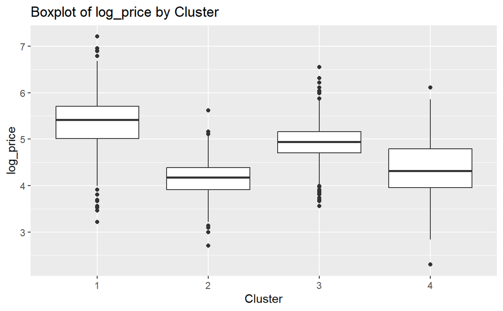

```r
# Boxplots for log_price by cluster
ggplot(ny_cluster.df, aes(x = cluster, y = log_price)) +
  geom_boxplot() +
  labs(x = "Cluster", y = "log_price") +
  ggtitle("Boxplot of log_price by Cluster")
```

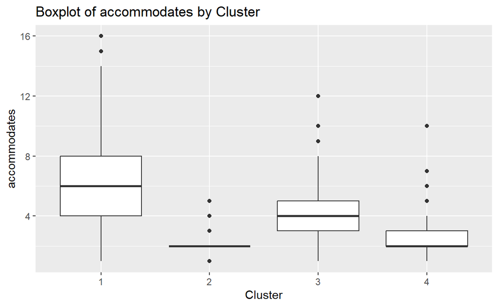

```r
# Boxplots for accommodates by cluster
ggplot(ny_cluster.df, aes(x = cluster, y = accommodates)) +
  geom_boxplot() +
  labs(x = "Cluster", y = "accommodates") +
  ggtitle("Boxplot of accommodates by Cluster")
```

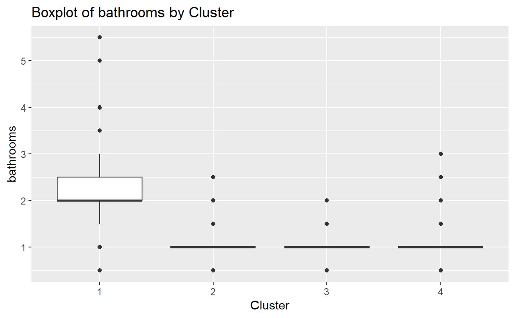

```r
# Boxplots for bathrooms by cluster
ggplot(ny_cluster.df, aes(x = cluster, y = bathrooms)) +
  geom_boxplot() +
  labs(x = "Cluster", y = "bathrooms") +
  ggtitle("Boxplot of bathrooms by Cluster")
```

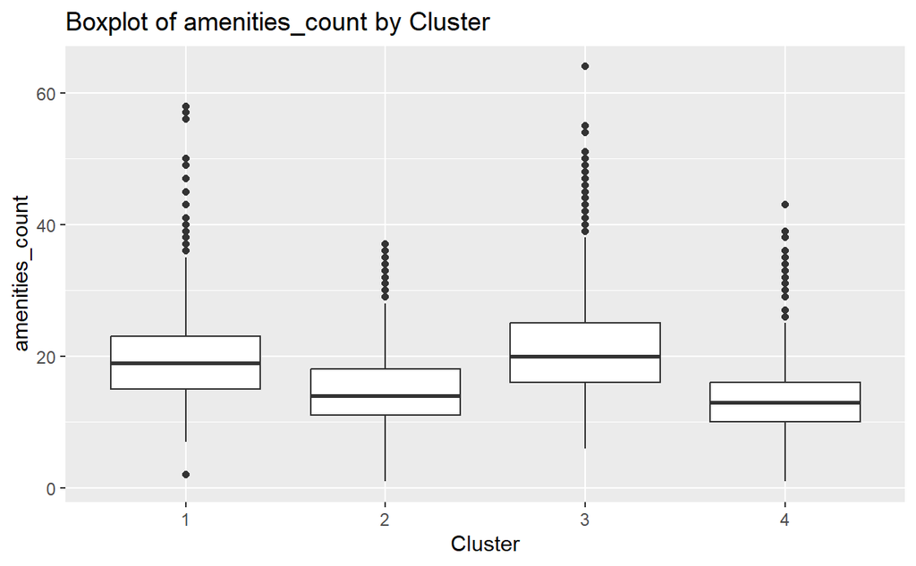

```r
# Boxplots for amenities_count by cluster
ggplot(ny_cluster.df, aes(x = cluster, y = amenities_count)) +
  geom_boxplot() +
  labs(x = "Cluster", y = "amenities_count") +
  ggtitle("Boxplot of amenities_count by Cluster")
```

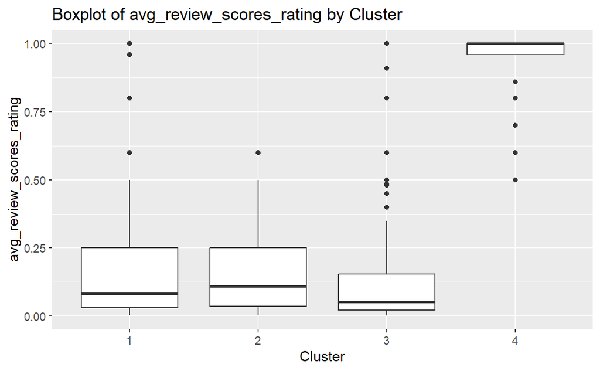

```r
# Boxplots for avg_review_scores_rating by cluster
ggplot(ny_cluster.df, aes(x = cluster, y = avg_review_scores_rating)) +
  geom_boxplot() +
  labs(x = "Cluster", y = "avg_review_scores_rating") +
  ggtitle("Boxplot of avg_review_scores_rating by Cluster")
```